# SEM database assembly

Author

Emma Belaud

**Purpose of this document**

This script is the **first step** of the SEM pipeline. It assembles all input variables from raw sensor and image data into a single analysis-ready database. Its outputs feed directly into:

- `2_SEM_diagnostic.qmd` — sensitivity analysis to select the optimal model configuration
- `3_SEM_modelisation.qmd` — full rolling-window SEM execution
- `4_SEM_results_analysis.qmd` — figure production and ecological interpretation

| Output | File | Description |
| --- | --- | --- |
| Main SEM database | `SEM_database.csv` | One row per scanner × time step, with fauna counts, environmental variables, root metrics, and season labels |
| Taxa list | `fauna_vars.txt` | Names of invertebrate taxa retained for modelling (≥ 5% of total observations) |
| Microclimate indices | `microclimate_index.txt` | The two most informative and orthogonal microclimatic summary variables, selected by PCA |
| Pipeline config | `pipeline_config.json` | Time step, step_hours, steps_per_day |

# 1 Data sources and processing steps

Five data streams are integrated:

| Step | Source | Key processing |
| --- | --- | --- |
| **1. Fauna detections** | In-situ scanner images | Filter to canonical scan times; recode fine taxa to higher levels; fill unobserved combinations with 0 (absent) vs. NA (missing image) |
| **2. Soil probes** | DIAMS sensors | Join by date × depth × position |
| **3. Microclimatic indices** | Derived from probes | Compute five rolling-window indices per variable; select the two most orthogonal via PCA (cos² ≥ 0.8) |
| **4. Root density** | Root pixel count images | Compute 9-day and 24-hour growth metrics using backward rolling joins (`data.table`); convert pixel counts to cm² |
| **5. Seasons** | Standard calendar dates | Equinox/solstice boundaries, 2023–2025 |

**Key design choices**

*Taxonomic lumping* — Fine-level taxa (e.g. *julida*, *polydesmida*) are promoted to their parent group (e.g. *diplopoda*) when too rare to model independently. The mapping is explicit in the code.

*Missing data encoding* — The distinction between 0 (taxon absent, scanner active) and NA (scanner produced no image) is preserved throughout the pipeline. Downstream scripts filter windows by data completeness rate rather than imputing.

*Microclimate dimensionality reduction* — Five indices summarise each variable over a rolling window (following Grooss et al., 2026). PCA then selects the two indices that are both well-represented on the first two PCA axes (cos² ≥ 0.8) and maximally orthogonal, minimising collinearity in the SEM.

# 2 Package loading

```r
library(tidyverse)   # Data wrangling and visualisation
library(lubridate)   # Date/time manipulation
library(ade4)        # Multivariate analysis (PCA)
library(jsonlite)    # Reading the taxonomic hierarchy JSON
library(zoo)         # Rolling window calculations
library(data.table)  # High-performance joins for root data
```

# 3 Pipeline configuration

```r
# Time step options:
#   "6 hours"  → raw scan resolution (default)
#   "1 day"    → daily aggregates
#   "12 hours" → twice-daily aggregates
TIME_STEP       <- "1 day"

# Derive everything else from TIME_STEP automatically
step_hours      <- as.numeric(lubridate::duration(TIME_STEP), "hours")
steps_per_day   <- 24 / step_hours          # e.g. 4 for 6h, 1 for daily
window_size     <- 4 * steps_per_day        # always ~1 day of rolling context

# Rolling join tolerances scale with the step size
tol_9d_secs     <- (2  + step_hours / 24) * 86400   # ±2 days + 1 step margin
tol_1d_secs     <- (0.5 + step_hours / 48) * 86400  # ±12 h + half-step margin

# Canonical scan hours that exist in the raw data (always 6-hour native res)
NATIVE_HOURS    <- c(0, 6, 12, 18)
```

# 4 Fauna data

## 4.1 Loading and cleaning raw detections

Images are acquired every 6 hours (00:00, 06:00, 12:00, 18:00). Scanner IDs encode positional metadata:

- **Character 4** → position (A, B, C): tree cover / intermediate / cultivated
- **Characters 5–6** → depth (20 or 50 cm)
- **Character 8** → orientation (O: West, E: East)

```r
df_raw <- read.csv("../data/fauna_data.csv",
                   sep = ",",
                   na.strings = c("", "NA", "background"))

df_raw <- df_raw %>%
  # Remove rows without a valid prediction
  filter(!is.na(Predicted.class)) %>%
  # Remove non-faunal, ambiguous, or composite classes
  filter(!Predicted.class %in% c(
    "under_threshold", "nodule", "SOM",
    "root_myccorhized", "fungi", "unknown", "multi_taxa"
  )) %>%
  mutate(
    # Decode scanner ID into structural covariates
    position    = substr(scanner, 4, 4),
    depth       = substr(scanner, 5, 6),
    orientation = substr(scanner, 8, 8),
    # Parse and correct timestamps (MM:01 → MM:00 artefact)
    date   = ymd_hms(date),
    date   = if_else(minute(date) == 1, date - minutes(1), date),
    hour   = hour(date),
    minute = minute(date)
  ) %>%
  # Restrict to the main study period
  filter(date > "2024-04-01 00:00:00") %>%
  # Keep only the four canonical daily scan times
  filter(minute == 0, hour %in% NATIVE_HOURS)
```

## 4.2 Build invertebrate taxa list from taxonomic hierarchy

Reads the hierarchical taxonomy JSON, extracts terminal (leaf) taxa under the “fauna” node, applies taxonomic lumping for small or structurally similar groups, and retains only taxa that represent ≥ 5% of total observations.

```r
# Load hierarchical taxonomy
taxo <- fromJSON("/home/Shared/hierarchy.json")

# Remove empty nodes
taxo_filtered <- taxo[sapply(taxo, function(x) length(x) > 0)]

# Recursive helper: collect all descendants of a given node
get_descendants <- function(node, tree) {
  children <- tree[[node]]
  if (is.null(children) || length(children) == 0) return(character(0))
  all_desc <- unlist(lapply(children, get_descendants, tree = tree),
                     use.names = FALSE)
  unique(c(children, all_desc))
}

# All taxa nested under "fauna"
all_fauna <- get_descendants("fauna", taxo_filtered)

# Keep only terminal (leaf) taxa — those with no children
leaves <- all_fauna[!sapply(all_fauna, function(x) {
  !is.null(taxo_filtered[[x]]) && length(taxo_filtered[[x]]) > 0
})]

# Manually exclude non-useful leaves
all_fauna_nodes <- get_descendants("fauna", taxo_filtered)
to_exclude <- c("multi_taxa", "unknown", "egg", "pauropoda_symphyla")

# Promote fine-level subgroups to their parent taxonomic level
# (used when subgroups are too rare to model independently)
rename_map <- c(
  "bdelloidea"      = "trombidiformes",
  "uropodina"       = "mesostigmata",
  "julida"          = "diplopoda",
  "polydesmida"     = "diplopoda",
  "polyxenida"      = "diplopoda",
  "geophilomorpha"  = "chilopoda",
  "lithobiomorpha"  = "chilopoda"
)

# Filter observations: recode promoted taxa, keep leaves only,
# and retain taxa representing ≥ 5% of all observations
taxa_list <- df_raw %>%
  mutate(Predicted.class = ifelse(
    Predicted.class %in% names(rename_map),
    rename_map[Predicted.class],
    Predicted.class
  )) %>%
  filter(Predicted.class %in% all_fauna_nodes,
         !Predicted.class %in% to_exclude) %>%
  group_by(Predicted.class) %>%
  mutate(n_taxon = n()) %>%
  ungroup() %>%
  mutate(prop_taxon = n_taxon / n()) %>%
  filter(prop_taxon >= 0.05)

# Export the retained taxa names for downstream scripts
writeLines(unique(taxa_list$Predicted.class), con = "../output/fauna_vars.txt")
```

## 4.3 Function: filter taxa by minimum occurrence count

Recodes specific taxa to a higher taxonomic level and, optionally, drops taxa below a given occurrence threshold. Set `filter_taxa = FALSE` to keep all taxa.

```r
#' Filter fauna dataframe by minimum occurrence count
#'
#' @param df           Fauna dataframe with a `Predicted.class` column.
#' @param filter_taxa  Logical. If TRUE, drop taxa below `min_occurrences`.
#' @param min_occurrences Integer. Minimum total detections to retain a taxon.
#' @return Dataframe with an additional `taxa_levelup` column and,
#'         if `filter_taxa = TRUE`, rows restricted to frequent taxa.
filter_taxa_df <- function(df, filter_taxa = TRUE, min_occurrences = 3000) {

  # Lump fine-level groups into broader taxa
  df <- df %>%
    mutate(taxa_levelup = case_when(
      Predicted.class %in% c("pseudosinella", "poduromorpha") ~ "collembola",
      Predicted.class %in% c("trombidiformes", "mesostigmata")  ~ "acari",
      Predicted.class %in% c("julida", "polydesmida", "polyxenida") ~ "diplopoda",
      Predicted.class %in% c("geophilomorpha", "lithobiomorpha")    ~ "chilopoda",
      TRUE ~ Predicted.class
    ))

  if (filter_taxa) {
    relevant_taxa <- df %>%
      group_by(Predicted.class) %>%
      summarise(total_occurrences = n(), .groups = "drop") %>%
      filter(total_occurrences >= min_occurrences) %>%
      select(Predicted.class)

    df <- df %>% filter(Predicted.class %in% relevant_taxa$Predicted.class)
    cat(nrow(relevant_taxa), "selected taxa:", relevant_taxa$Predicted.class, "\n")
  }

  return(df)
}

# Apply without occurrence filter (keep all taxa)
df_filtered <- filter_taxa_df(df_raw, filter_taxa = FALSE)
```

## 4.4 Build the complete abundance matrix

Creates a full time × scanner grid, counts detections per taxon per image, and fills unobserved taxon–date–scanner combinations with **0** (taxon absent). Images with no scan at all remain **NA** (data missing).

```r
# Grid at the chosen time step
seq_time <- seq(floor_date(min(df_raw$date), TIME_STEP),
                floor_date(max(df_raw$date), TIME_STEP),
                by = TIME_STEP)

complete_grid <- expand_grid(date = seq_time, scanner = unique(df_raw$scanner))

# Aggregate counts to the chosen resolution before pivoting
df_complete <- df_filtered %>%
  mutate(date = floor_date(date, TIME_STEP)) %>%
  group_by(taxa_levelup, date, scanner, depth, position, orientation) %>%
  reframe(count = n()) %>%
  mutate(presence = 1) %>%
  pivot_wider(names_from = taxa_levelup, values_from = count, values_fill = 0)

# Left-join against the complete grid:
#   - 0 if the scanner was active but the taxon was absent
#   - NA if the scanner produced no image at that time step
df_complete <- complete_grid %>%
  mutate(
    position    = as.factor(substr(scanner, 4, 4)),
    depth       = as.factor(substr(scanner, 5, 6)),
    orientation = as.factor(substr(scanner, 8, 8))
  ) %>%
  left_join(df_complete,
            by = c("date", "scanner", "depth", "position", "orientation")) %>%
  mutate(presence = replace_na(presence, 0))

# Total abundance across all numeric taxa columns (NA propagates if any are NA)
df_complete <- df_complete %>%
  mutate(all_taxa = rowSums(select(., where(is.numeric), -presence),
                            na.rm = FALSE)) %>%
  ungroup()
```

## 4.5 Figure 1 — Missing data by scanner and month

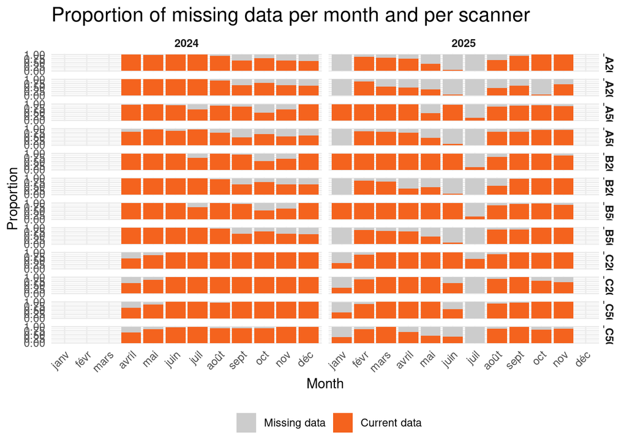

Figure 1: **Proportion of missing vs. acquired images per scanner and month.** Each bar stack sums to 1. Orange = image acquired; grey = missing (scanner downtime or quality-control filter). Facets are arranged by scanner identity (rows) and calendar year (columns).

```r
df_complete %>%
  mutate(
    year  = as.factor(year(date)),
    month = as.factor(lubridate::month(date, label = TRUE, abbr = TRUE))
  ) %>%
  group_by(scanner, year, month, presence) %>%
  summarise(n = n(), .groups = "drop") %>%
  group_by(scanner, year, month) %>%
  mutate(prop = n / sum(n)) %>%
  ggplot(aes(x = month, y = prop, fill = as.factor(presence))) +
  geom_bar(stat = "identity", position = "stack") +
  facet_grid(scanner ~ year) +
  scale_fill_manual(
    values = c("0" = "grey80", "1" = "#F4631E"),
    labels = c("0" = "Missing data", "1" = "Current data")
  ) +
  labs(
    title = "Proportion of missing data per month and per scanner",
    x = "Month", y = "Proportion", fill = ""
  ) +
  theme_minimal() +
  theme(
    strip.text      = element_text(face = "bold"),
    axis.text.x     = element_text(angle = 45, hjust = 1),
    legend.position = "bottom",
    plot.title      = element_text(size = 16)
  )
```

## 4.6 Land-use grouping and SEM base table

Two land-use categories are compared:

| Code | Land use | Scanner position |
| --- | --- | --- |
| 0 | Tree cover + herbaceous | A |
| 1 | Cultivated cover | C |

Position **B** (intermediate strip) is excluded from the analysis.

```r
data_sem <- df_complete %>%
  filter(position != "B") %>%
  mutate(
    depth   = as.factor(depth),
    scanner = as.factor(scanner),
    year    = as.factor(year(date)),
    month   = floor_date(date, unit = "month"),
    week    = floor_date(date, unit = "week")
  )
```

## 4.7 Function: filter dates with insufficient scanner coverage

```r
#' Flag (and optionally remove) dates with low scanner coverage
#'
#' @param data       SEM dataframe.
#' @param min_images Integer. Minimum number of active scanners required.
#' @param apply_filter Logical. If TRUE, remove flagged dates.
#' @return The input dataframe with added columns `images_count` and
#'         `dates_to_keep`, plus a coverage barplot (Figure S1.2).
filter_data <- function(data, min_images = 6, apply_filter = FALSE) {

  data <- data %>%
    group_by(date) %>%
    mutate(
      images_count  = sum(presence),
      dates_to_keep = as.factor(as.integer(images_count > min_images)),
      presence      = as.factor(presence)
    ) %>%
    ungroup() %>%
    mutate(
      year  = as.factor(year(date)),
      month = as.factor(lubridate::month(date, label = TRUE, abbr = TRUE))
    )

  data_for_plot <- data
  if (apply_filter) data_for_plot <- data_for_plot %>% filter(dates_to_keep == 1)

  # Figure S1.2
  data_for_plot %>%
    group_by(scanner, year, month, dates_to_keep) %>%
    summarise(n = n(), .groups = "drop") %>%
    group_by(scanner, year, month) %>%
    mutate(prop = n / sum(n)) %>%
    ggplot(aes(x = month, y = prop, fill = dates_to_keep)) +
    geom_bar(stat = "identity", position = "stack") +
    facet_grid(~ year) +
    scale_fill_manual(
      values = c("0" = "grey80", "1" = "#00A86B"),
      labels = c("0" = "Missing data", "1" = "Current data")
    ) +
    labs(
      title = "Proportion of data retained per month and per scanner",
      x = "Month", y = "Proportion", fill = ""
    ) +
    theme_minimal() +
    theme(
      strip.text      = element_text(face = "bold"),
      axis.text.x     = element_text(angle = 45, hjust = 1),
      legend.position = "bottom",
      plot.title      = element_text(size = 16)
    )

  return(data)
}

# Flag dates but keep all of them (apply_filter = FALSE)
data_sem <- filter_data(data_sem, min_images = 6, apply_filter = FALSE)
```

# 5 Environmental data

```r
# Soil temperature and humidity (position × depth × date)
soil_probe_data <- read.csv("../data/Diams_AF1W_soil.csv") %>%
  mutate(
    date     = as.POSIXct(date, format = "%Y-%m-%d %H:%M:%S"),
    depth    = as.factor(depth),
    position = as.factor(position)
  ) %>%
  drop_na()

# Merge environmental variables into the main dataframe
data_sem <- data_sem %>%
  left_join(soil_probe_data, by = c("date", "depth", "position"))
```

# 6 Microclimatic indices

## 6.1 Index parameters

```r
missing_data_rate <- 0.3     # Max fraction of NAs tolerated within a window
```

## 6.2 Compute rolling microclimatic indices

Following Grooss et al. (2026), five indices summarise each environmental variable over the rolling window:

| Index | Description |
| --- | --- |
| `median` | Central tendency, robust to extremes |
| `amplitude` | 5th–95th percentile range (within-window variability) |
| `change_ratio` | Median of successive differences (instantaneous variability) |
| `max` | 97.5th percentile (warm/wet extreme) |
| `min` | 2.5th percentile (cold/dry extreme) |

```r
vars_to_index <- c("temp_soil", "hum_soil")
index_names   <- c("median", "amplitude", "change_ratio", "max", "min")

#' Compute five summary indices for a numeric vector.
#' Returns all-NA if more than `missing_data_rate` of values are missing.
index_compute_function <- function(vec) {
  if (mean(is.na(vec)) > missing_data_rate) {
    return(c(median = NA, amplitude = NA, change_ratio = NA, max = NA, min = NA))
  }
  qs    <- quantile(vec, c(0.025, 0.05, 0.95, 0.975), na.rm = TRUE)
  diffs <- diff(round(vec, 6))
  c(median       = median(vec, na.rm = TRUE),
    amplitude    = qs[3] - qs[2],
    change_ratio = median(diffs, na.rm = TRUE),
    max          = unname(qs[4]),
    min          = unname(qs[1]))
}

# Apply rolling window within each position × orientation × depth group
data_sem_indices <- data_sem %>%
  arrange(position, orientation, depth, date) %>%
  group_by(position, orientation, depth) %>%
  mutate(
    across(
      all_of(vars_to_index),
      ~ {
        m <- rollapplyr(.x, window_size, index_compute_function,
                        by.column = FALSE, fill = NA)
        colnames(m) <- index_names
        as_tibble(m)
      },
      .names  = "{.col}",
      .unpack = TRUE
    )
  ) %>%
  ungroup()
```

## 6.3 Select the two most informative, orthogonal indices via PCA

A PCA is performed on all computed indices. The two well-represented variables (cos² ≥ 0.8) with the smallest mutual cosine (most orthogonal in PCA space) are retained for the SEM.

```r
# Prepare complete-case matrix of all indices
microclim_data <- data_sem_indices %>%
  select(starts_with("temp_soil_"), starts_with("hum_soil_")) %>%
  drop_na() %>%
  select(where(~ sd(.x, na.rm = TRUE) > 0))

# PCA (2 axes)
acp_microclimate <- dudi.pca(microclim_data, scannf = FALSE, nf = 2)
# s.corcircle(acp_microclimate$co)  # Uncomment to visualise variable loadings

var_coord <- acp_microclimate$co[, 1:2]
var_names <- rownames(var_coord)

# Quality of representation: cos² per variable (sum of squared loadings)
var_cos2  <- rowSums(var_coord^2)
good_vars <- var_names[var_cos2 >= 0.8]

# Cosine of the angle between two loading vectors (measure of collinearity)
cos_angle <- function(v1, v2) sum(v1 * v2) / (sqrt(sum(v1^2)) * sqrt(sum(v2^2)))

# Among well-represented variables, find the most orthogonal pair
pair_matrix        <- combn(good_vars, 2)
i_min              <- which.min(apply(pair_matrix, 2, function(p) {
  cos_angle(var_coord[p[1], ], var_coord[p[2], ])
}))
microclimate_index <- pair_matrix[, i_min]

cat("Microclimate indices selected:", microclimate_index[1], "and", microclimate_index[2])
```

```
Microclimate indices selected: temp_soil_max and hum_soil_max
```

```r
# Add the two selected indices back to the main dataframe
data_sem <- data_sem %>%
  left_join(
    data_sem_indices %>%
      select(date, position, orientation, depth, all_of(microclimate_index)),
    by = c("date", "position", "orientation", "depth")
  )

# Export selected index names for downstream scripts
writeLines(microclimate_index, con = "../output/microclimate_index.txt")
```

# 7 Root density data

## 7.1 Constants

```r
dpi              <- 1200
pixels_per_cm_sq <- (dpi / 2.54)^2   # Conversion factor: pixels → cm²
```

## 7.2 Load and parse root pixel counts

```r
root_density_raw <- fread("../data/root_pixels_count.csv")

root_density <- root_density_raw[, `:=`(
  image_name = sub("\\.png$", "", file)
)][, c("bloc", "pos", "orient", "yr", "mon", "day", "hr", "min", "ext") :=
     tstrsplit(file, "_|\\.|H|M.| |-", fill = NA)
][, date := ymd_hm(paste(yr, mon, day, hr, min))]

root_density[, date   := as.POSIXct(date)]
root_density[, minute := minute(date)]
root_density[minute == 1, date := date - 60]
root_density <- root_density[minute(date) == 0 & hour(date) %in% NATIVE_HOURS]

root_density[, `:=`(
  scanner     = as.factor(paste(pos, orient, sep = "_")),
  depth       = as.factor(substr(pos, 2, 3)),
  position    = as.factor(substr(pos, 1, 1)),
  orientation = as.factor(orient)
)]

setkey(root_density, depth, position, orientation, date)
```

## 7.3 Rolling joins to retrieve lagged pixel counts

```r
root_density[, `:=`(
  date_target_9d = date - days(9),
  date_target_1d = date - days(1)
)]

# --- 9-day lag (tolerance: ≤ 2 days = 172 800 s) ---
ref_9d <- root_density[, .(depth, position, orientation,
                           date_found_9d = date,
                           pixels_9d    = root_pixels_count)]
setkey(ref_9d, depth, position, orientation, date_found_9d)

root_density <- ref_9d[root_density,
                       on  = .(depth, position, orientation,
                               date_found_9d = date_target_9d),
                       roll = +Inf]

root_density[, diff_9d := abs(as.numeric(difftime(date_found_9d, date - days(9), units = "secs")))]
root_density[, root_pixels_count_lag := ifelse(diff_9d <= tol_9d_secs, pixels_9d, NA)]
root_density[, c("date_found_9d", "pixels_9d", "diff_9d") := NULL]

# --- 1-day lag (tolerance: ≤ 12 hours = 43 200 s) ---
ref_1d <- root_density[, .(depth, position, orientation,
                           date_found_1d = date,
                           pixels_1d    = root_pixels_count)]
setkey(ref_1d, depth, position, orientation, date_found_1d)

root_density <- ref_1d[root_density,
                       on  = .(depth, position, orientation,
                               date_found_1d = date_target_1d),
                       roll = +Inf]

root_density[, diff_1d := abs(as.numeric(difftime(date_found_1d, date - days(1), units = "secs")))]
root_density[, root_pixels_count_lag_1d := ifelse(diff_1d <= tol_1d_secs, pixels_1d, NA)]
root_density[, c("date_found_1d", "pixels_1d", "diff_1d") := NULL]
```

## 7.4 Compute root area metrics

```r
root_density[, `:=`(
  root_growth_pixel_count    = root_pixels_count - root_pixels_count_lag,
  root_growth_pixel_count_1d = root_pixels_count - root_pixels_count_lag_1d
)]

root_density[, `:=`(
  root_cm2_count            = root_pixels_count / pixels_per_cm_sq,
  root_growth_cm2_count     = root_growth_pixel_count    / pixels_per_cm_sq,
  root_mature_cm2_count     = (root_pixels_count - root_growth_pixel_count) / pixels_per_cm_sq,
  root_growth_cm2_count_24h = root_growth_pixel_count_1d / pixels_per_cm_sq
)]

# Treat negative 24 h growth as zero (sensor noise / root turnover not modelled)
root_density[root_growth_cm2_count_24h < 0, root_growth_cm2_count_24h := 0]
```

## 7.5 Merge root metrics into the SEM dataframe

```r
setDT(data_sem)

data_sem <- merge(
  data_sem,
  root_density[, .(date, position, depth, orientation,
                   root_cm2_count, root_growth_cm2_count,
                   root_mature_cm2_count, root_growth_cm2_count_24h)],
  by  = c("date", "position", "depth", "orientation"),
  all.x = TRUE
)
```

# 8 Season variable

Seasons are defined by astronomical boundaries (equinoxes and solstices), covering 2023–2025.

```r
years  <- 2023:2025
season <- c("spring", "summer", "autumn", "winter")

seasons <- bind_rows(lapply(years, function(an) {
  tibble(
    season     = season,
    date_debut = as.Date(paste0(an, c("-03-21", "-06-21", "-09-21", "-12-21"))),
    date_fin   = as.Date(paste0(
      c(an, an, an, an + 1),
      c("-06-20", "-09-20", "-12-20", "-03-20")
    ))
  )
}))

data_sem <- data_sem %>%
  mutate(day = as.Date(date)) %>%
  left_join(
    seasons %>%
      rowwise() %>%
      mutate(day = list(seq(date_debut, date_fin, by = "day"))) %>%
      unnest(cols = c(day)) %>%
      dplyr::select(day, season),
    by = "day"
  )
```

# 9 Data summary

```
Period          : 2024-04-01 → 2025-11-17 (595 days)
```

```
Images (total)  : 18,634
```

```
Occ. raw        : 128,155
```

```
Occ. filtered   : 121,378
```

```
Taxa retained   : 6  [acari, collembola, diplopoda, enchytraeidae, gastropoda, symphyla]
```

```
Scanners        : 12  (A=4 treed, C=4 cultivated)
```

```
SEM grid rows   : 4,788
```

```
Missing images  : 1,122 / 4,788  (23.4%)
```

```
Missing rate per scanner:
```

```
  scanner position n_total n_missing pct_miss
 AF_A20_E        A     596       180     30.2
 AF_A20_O        A     596       247     41.4
 AF_A50_E        A     616       106     17.2
 AF_A50_O        A     596       209     35.1
 AF_C20_E        C     596        56      9.4
 AF_C20_O        C     596        97     16.3
 AF_C50_E        C     596        89     14.9
 AF_C50_O        C     596       138     23.2
```

# 10 Export

The following files are written to `../output/` for use by S2–S4:

```r
data_sem$date <- format(data_sem$date, "%Y-%m-%d %H:%M:%S")
write.csv(data_sem, "../output/SEM_database.csv", row.names = FALSE, quote = TRUE)

jsonlite::write_json(
  list(time_step     = TIME_STEP,
       step_hours    = step_hours,
       steps_per_day = steps_per_day),
  "../output/pipeline_config.json",
  pretty = TRUE
)

message(sprintf(
  "Export complete.
  SEM database : %s rows | %d scanners | %d taxa
  Time step    : %s (%g h)
  Period       : %s → %s",
  format(n_rows_total, big.mark = ","),
  n_scanners, n_taxa,
  TIME_STEP, step_hours,
  format(period_start, "%Y-%m-%d"),
  format(period_end,   "%Y-%m-%d")
))
```

| Output file | Contents |
| --- | --- |
| `SEM_database.csv` | Main modelling database (one row per scanner × time step) |
| `fauna_vars.txt` | Retained taxa names (one per line) |
| `microclimate_index.txt` | Selected microclimate index names (one per line) |
| `pipeline_config.json` | TIME_STEP, step_hours, steps_per_day |